# desilike

## Framework to specify DESI (clustering) likelihoods

### Tutorial #2: bindings with external inference codes

# Goals

At the end of the tutorial you will know:

- how to write likelihoods in terms of compressed parameters (e.g. based on forecasts), optionally with covariance between different measurements
- how to write full shape likelihoods, and emulate their theory
- how to run inference within desilike, or [Cobaya](https://github.com/CobayaSampler/cobaya), [CosmoSIS](https://github.com/joezuntz/cosmosis), and [MontePython](https://github.com/brinckmann/montepython_public).

For real-life examples, see the application to [mock Y1 cosmological inference](https://github.com/cosmodesi/desi-y1-kp7/tree/main/mock_y1).

This is the continuation of the first tutorial, accessible here: https://github.com/cosmodesi/desilike-tutorials.

# Environment

Easiest is to use the cosmodesi environment at NERSC:

```
source /global/common/software/desi/users/adematti/cosmodesi_environment.sh main  # source the environment
${COSMODESIMODULES}/install_jupyter_kernel.sh main  # this to be done once
```

NB: to remove the previous kernel:

```
rm -rf ${HOME}/.local/share/jupyter/kernels/cosmodesi-main
```

To see these slides in a browser, e.g.:

```
firefox desilike_bindings.slides.html
```

# Compressed likelihoods

Let's first focus on compressed likelihoods = only depend on the cosmological model (nuisance = bias, stochastic and counterterms already marginalized out).

=> sampling of these likelihoods is typically fast enough that they do not need to be emulated.

## BAO likelihood

BAO likelihoods are built from a "BAO observable", that compares a data vector to a theory, typically $\alpha_{\perp}$ and $\alpha_{\parallel}$ or $D_{M}/r_{d}$ and $D_{H}/r_{d}$.

```python
import numpy as np

from desilike import utils, setup_logging
from desilike.likelihoods import ObservablesGaussianLikelihood
from desilike.observables.galaxy_clustering import BAOCompressionObservable

setup_logging()

# fiducial cosmology is DESI's by default
observable1 = BAOCompressionObservable(data=[1., 1.],
                                       covariance=np.diag([0.01, 0.01]),
                                       quantities=['qpar', 'qper'],
                                       z=1.)
# Let's define the likelihood from this observable
likelihood = ObservablesGaussianLikelihood(observable1)
```

### Reminder

```python
# Likelihood parameters
print('varied likelihood parameters are', likelihood.varied_params.names())
# To evaluate the likelihood (return the logposterior)
print('logposterior is {:.3f}'.format(likelihood(Omega_m=0.29)))
```

```
[000000.14] [0/1] 08-29 17:47  BAOCompressionObservable  INFO     Found quantities ['qpar', 'qper'].
varied likelihood parameters are ['Omega_m']
logposterior is -0.005
```

Why do we bother about "observables"?

... because we can join them in a likelihood!

```python
# We want to share the same cosmological calculation among all observables
# so let's give it explicitly
from desilike.theories import Cosmoprimo
cosmo = Cosmoprimo(fiducial='DESI')
# Set Cosmoprimo calculator's parameters
cosmo.init.params = {'Omega_m': {'prior': {'limits': [0.1, 0.9]},
                                 'ref': {'dist': 'norm', 'loc': 0.3, 'scale': 0.002},
                                 'latex': '\Omega_m'}}
# Let's reuse the first observable we have defined, just updating the cosmo
observable1.init.update(cosmo=cosmo)
# Let's be fancy and rather define our observable in terms of DV_over_rd
# We provide a dictionary to "data": the theory vector will be generated automatically
observable2 = BAOCompressionObservable(data={}, quantities=['DV_over_rd'], z=1.5, cosmo=cosmo)
# Let's join the two observables, and provide the joint covariance
likelihood = ObservablesGaussianLikelihood([observable1, observable2],
                                           covariance=np.diag([0.01, 0.01, 1.]))
print('likelihood is {:.4f}'.format(likelihood()))
```

```
[000000.93] [0/1] 08-29 17:47  BAOCompressionObservable  INFO     Found quantities ['qpar', 'qper'].
[000001.22] [0/1] 08-29 17:47  BAOCompressionObservable  INFO     Found quantities ['DV_over_rd'].
likelihood is -0.0000
```

We can also sum (log-) likelihoods!

```python
likelihood2 = likelihood + likelihood
likelihood(Omega_m=0.29)
likelihood2(Omega_m=0.29)
assert np.allclose(likelihood2.loglikelihood, 2. * likelihood.loglikelihood)
```

## Bindings

To generate desilike bindings, let's start by writing a callable (~ "function") that returns the desilike likelihood.

```python
def BAOLikelihood(cosmo='external'):
    # cosmo = 'external' to tell desilike that cosmo will be provided externally
    # = by the external cosmological inference code
    observable1 = BAOCompressionObservable(data=[1., 1.], quantities=['qpar', 'qper'], z=0.5,
                                           cosmo=cosmo)
    observable2 = BAOCompressionObservable(data=[1.], quantities=['qiso'], z=1., cosmo=cosmo)
    likelihood = ObservablesGaussianLikelihood([observable1, observable2],
                                               covariance=np.diag([0.002, 0.002, 0.005]))
    return likelihood
```

### Cobaya

### 'Dynamic' bindings

Cobaya is built such that we can provide likelihoods defined on-the-fly (i.e. not in a Python script), and run inference from Python directly.

```python
from desilike.bindings.cobaya import CobayaLikelihoodFactory

# CobayaBAOLikelihood is a Cobaya Likelihood object
CobayaBAOLikelihood = CobayaLikelihoodFactory(BAOLikelihood, params=True)
```

```
[000001.93] [0/1] 08-29 17:47  BAOCompressionObservable  INFO     Found quantities ['qpar', 'qper'].
[000002.02] [0/1] 08-29 17:47  BAOCompressionObservable  INFO     Found quantities ['qiso'].
[000002.29] [0/1] 08-29 17:47  numexpr.utils             INFO     NumExpr defaulting to 8 threads.
```

```python
from cosmoprimo.fiducial import DESI
cosmo = DESI()

# No magic here, this is all Cobaya stuff
params = {'Omega_m': {'prior': {'min': 0.1, 'max': 1.},
                      'ref': {'dist': 'norm', 'loc': 0.3, 'scale': 0.01},
                      'latex': '\Omega_{m}'},
          'omega_b': cosmo['omega_b'],
          'H0': cosmo['H0'],
          'A_s': cosmo['A_s'],
          'n_s': cosmo['n_s'],
          'tau_reio': cosmo['tau_reio']}

info = {'params': params,
        'likelihood': {'bao_likelihood': CobayaBAOLikelihood},
        'theory': {'classy': {'extra_args': {'N_ncdm': cosmo['N_ncdm'], 'N_ur': cosmo['N_ur']}}}}

from cobaya.model import get_model
model = get_model(info)
model.logposterior({'Omega_m': cosmo['Omega_m']})
```

```
[000002.63] [0/1] 08-29 17:47  classy                    INFO     `classy` module loaded successfully from /home/adematti/anaconda3/envs/cosmodesi-main/lib/python3.10/site-packages/classy-3.2.0-py3.10-linux-x86_64.egg
[000002.72] [0/1] 08-29 17:47  BAOCompressionObservable  INFO     Found quantities ['qpar', 'qper'].
[000002.81] [0/1] 08-29 17:47  BAOCompressionObservable  INFO     Found quantities ['qiso'].
```

```
LogPosterior(logpost=0.10471144781489065, logpriors=[0.10536051565782628], loglikes=array([-0.00064907]), derived=[], finite=False)
```

```python
# Let's run MCMC!
info_sampler = {'mcmc': {'Rminus1_stop': 0.02}}
from cobaya.sampler import get_sampler
mcmc = get_sampler(info_sampler, model=model)
mcmc.run()
```

```
[000006.55] [0/1] 08-29 17:47  mcmc                      INFO     Getting initial point... (this may take a few seconds)
[000006.63] [0/1] 08-29 17:47  model                     INFO     Measuring speeds... (this may take a few seconds)
[000006.88] [0/1] 08-29 17:47  model                     INFO     Setting measured speeds (per sec): {bao_likelihood: 262.0, classy: 12.7}
[000006.88] [0/1] 08-29 17:47  mcmc                      INFO     Initial point: Omega_m:0.3131897
[000006.89] [0/1] 08-29 17:47  mcmc                      INFO     Covariance matrix not present. We will start learning the covariance of the proposal earlier: R-1 = 30 (would be 2 if all params loaded).
[000006.90] [0/1] 08-29 17:47  mcmc                      INFO     Sampling!
[000006.98] [0/1] 08-29 17:47  mcmc                      INFO     Progress @ 2023-08-29 17:47:23 : 1 steps taken, and 0 accepted.
[000010.25] [0/1] 08-29 17:47  mcmc                      INFO     Learn + convergence test @ 40 samples accepted.
[000010.26] [0/1] 08-29 17:47  mcmc                      INFO      - Acceptance rate: 0.970
[000010.26] [0/1] 08-29 17:47  mcmc                      INFO      - Convergence of means: R-1 = 2.438626 after 32 accepted steps
[000010.26] [0/1] 08-29 17:47  mcmc                      INFO      - Updated covariance matrix of proposal pdf.
[000014.07] [0/1] 08-29 17:47  mcmc                      INFO     Learn + convergence test @ 80 samples accepted.
[000014.08] [0/1] 08-29 17:47  mcmc                      INFO      - Acceptance rate: 0.877
[000014.08] [0/1] 08-29 17:47  mcmc                      INFO      - Convergence of means: R-1 = 1.103960 after 64 accepted steps
[000014.08] [0/1] 08-29 17:47  mcmc                      INFO      - Updated covariance matrix of proposal pdf.
[000019.25] [0/1] 08-29 17:47  mcmc                      INFO     Learn + convergence test @ 120 samples accepted.
[000019.26] [0/1] 08-29 17:47  mcmc                      INFO      - Acceptance rate: 0.711
[000019.26] [0/1] 08-29 17:47  mcmc                      INFO      - Convergence of means: R-1 = 0.919164 after 96 accepted steps
[000019.26] [0/1] 08-29 17:47  mcmc                      INFO      - Updated covariance matrix of proposal pdf.
[000024.94] [0/1] 08-29 17:47  mcmc                      INFO     Learn + convergence test @ 160 samples accepted.
[000024.95] [0/1] 08-29 17:47  mcmc                      INFO      - Acceptance rate: 0.624
[000024.95] [0/1] 08-29 17:47  mcmc                      INFO      - Convergence of means: R-1 = 0.205332 after 128 accepted steps
[000024.95] [0/1] 08-29 17:47  mcmc                      INFO      - Updated covariance matrix of proposal pdf.
[000030.30] [0/1] 08-29 17:47  mcmc                      INFO     Learn + convergence test @ 200 samples accepted.
[000030.31] [0/1] 08-29 17:47  mcmc                      INFO      - Acceptance rate: 0.571
[000030.31] [0/1] 08-29 17:47  mcmc                      INFO      - Convergence of means: R-1 = 0.053204 after 160 accepted steps
[000030.31] [0/1] 08-29 17:47  mcmc                      INFO      - Updated covariance matrix of proposal pdf.
[000037.18] [0/1] 08-29 17:47  mcmc                      INFO     Learn + convergence test @ 240 samples accepted.
[000037.19] [0/1] 08-29 17:47  mcmc                      INFO      - Acceptance rate: 0.512
[000037.19] [0/1] 08-29 17:47  mcmc                      INFO      - Convergence of means: R-1 = 0.157320 after 192 accepted steps
[000037.19] [0/1] 08-29 17:47  mcmc                      INFO      - Updated covariance matrix of proposal pdf.
[000042.63] [0/1] 08-29 17:47  mcmc                      INFO     Learn + convergence test @ 280 samples accepted.
[000042.64] [0/1] 08-29 17:47  mcmc                      INFO      - Acceptance rate: 0.510
[000042.64] [0/1] 08-29 17:47  mcmc                      INFO      - Convergence of means: R-1 = 0.051815 after 224 accepted steps
[000042.65] [0/1] 08-29 17:47  mcmc                      INFO      - Updated covariance matrix of proposal pdf.
[000048.31] [0/1] 08-29 17:48  mcmc                      INFO     Learn + convergence test @ 320 samples accepted.
[000048.32] [0/1] 08-29 17:48  mcmc                      INFO      - Acceptance rate: 0.492
[000048.32] [0/1] 08-29 17:48  mcmc                      INFO      - Convergence of means: R-1 = 0.019829 after 256 accepted steps
[000048.32] [0/1] 08-29 17:48  mcmc                      INFO      - Updated covariance matrix of proposal pdf.
[000055.34] [0/1] 08-29 17:48  mcmc                      INFO     Learn + convergence test @ 360 samples accepted.
[000055.35] [0/1] 08-29 17:48  mcmc                      INFO      - Acceptance rate: 0.461
[000055.35] [0/1] 08-29 17:48  mcmc                      INFO      - Convergence of means: R-1 = 0.003976 after 288 accepted steps
[000055.37] [0/1] 08-29 17:48  mcmc                      INFO      - Convergence of bounds: R-1 = 0.152731 after 360 accepted steps
[000055.37] [0/1] 08-29 17:48  mcmc                      INFO     The run has converged!
[000055.38] [0/1] 08-29 17:48  mcmc                      INFO     Sampling complete after 360 accepted steps.
```

```
[000055.39] [0/1] 08-29 17:48  root                      WARNING  outlier fraction 0.1111111111111111
```

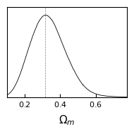

```python
from getdist.mcsamples import MCSamplesFromCobaya
samples_bao_cobaya = mcmc.samples(combined=True, skip_samples=0.5, to_getdist=True).copy(label='cobaya')
from getdist import plots
g = plots.get_subplot_plotter()
g.triangle_plot(samples_bao_cobaya, params=['Omega_m'], markers={'Omega_m': cosmo['Omega_m']})
```

### Interlude: let's do the same within desilike

```python
from desilike.samplers import MCMCSampler

from desilike.theories import Cosmoprimo
cosmo = Cosmoprimo(fiducial='DESI')
# Set Cosmoprimo calculator's parameters
cosmo.init.params = {'Omega_m': {'prior': {'limits': [0.1, 1.]},
                                 'ref': {'dist': 'norm', 'loc': 0.3, 'scale': 0.01},
                                 'latex': '\Omega_m'}}
sampler = MCMCSampler(BAOLikelihood(cosmo=cosmo), seed=42)
chains = sampler.run(check={'max_eigen_gr': 0.03, 'stable_over': 2}, check_every=40)
# do help(chains[0]) to get info on the available methods!
samples_bao_desilike = chains[0].remove_burnin(0.5).to_getdist(label='desilike')
```

```
[000056.30] [0/1] 08-29 17:48  BAOCompressionObservable  INFO     Found quantities ['qpar', 'qper'].
[000056.40] [0/1] 08-29 17:48  BAOCompressionObservable  INFO     Found quantities ['qiso'].
[000056.60] [0/1] 08-29 17:48  MCMCSampler               INFO     Varied parameters: ['Omega_m'].
[000057.60] [0/1] 08-29 17:48  BasePipeline              INFO     Found speeds:
[000057.60] [0/1] 08-29 17:48  BasePipeline              INFO     - <desilike.theories.primordial_cosmology.Cosmoprimo object at 0x7ff61037df90>: 446.58 iterations / second
[000057.60] [0/1] 08-29 17:48  BasePipeline              INFO     - <desilike.theories.galaxy_clustering.power_template.BAOExtractor object at 0x7ff610390190>: 12.02 iterations / second
[000057.60] [0/1] 08-29 17:48  BasePipeline              INFO     - <desilike.observables.galaxy_clustering.compression.BAOCompressionObservable object at 0x7ff61037ffa0>: 1985.85 iterations / second
[000057.60] [0/1] 08-29 17:48  BasePipeline              INFO     - <desilike.theories.galaxy_clustering.power_template.BAOExtractor object at 0x7ff610392380>: 3686.00 iterations / second
[000057.60] [0/1] 08-29 17:48  BasePipeline              INFO     - <desilike.observables.galaxy_clustering.compression.BAOCompressionObservable object at 0x7ff61037f7c0>: 4666.04 iterations / second
[000057.60] [0/1] 08-29 17:48  BasePipeline              INFO     - <desilike.likelihoods.base.ObservablesGaussianLikelihood object at 0x7ff610390430>: 2977.43 iterations / second
[000061.80] [0/1] 08-29 17:48  MCMCSampler               INFO     Diagnostics:
[000061.80] [0/1] 08-29 17:48  MCMCSampler               INFO     - max eigen Gelman-Rubin - 1 is 1.6; not < 0.03.
[000061.81] [0/1] 08-29 17:48  MCMCSampler               INFO     - max diag Gelman-Rubin - 1 is 1.6.
[000061.84] [0/1] 08-29 17:48  MCMCSampler               INFO     - max diag Gelman-Rubin - 1 at 1.0 sigmas is 2.04.
[000061.84] [0/1] 08-29 17:48  MCMCSampler               INFO     - max Geweke is nan.
[000061.84] [0/1] 08-29 17:48  MCMCSampler               INFO     - Geweke p-value is nan.
[000061.84] [0/1] 08-29 17:48  MCMCSampler               INFO     - (20 iterations / integrated autocorrelation time) is 32.5.
[000061.95] [0/1] 08-29 17:48  MCMCSampler               INFO     Updating proposal covariance.
[000067.49] [0/1] 08-29 17:48  MCMCSampler               INFO     Diagnostics:
[000067.50] [0/1] 08-29 17:48  MCMCSampler               INFO     - max eigen Gelman-Rubin - 1 is 1.07; not < 0.03.
[000067.50] [0/1] 08-29 17:48  MCMCSampler               INFO     - max diag Gelman-Rubin - 1 is 1.07.
[000067.52] [0/1] 08-29 17:48  MCMCSampler               INFO     - max diag Gelman-Rubin - 1 at 1.0 sigmas is 3.79.
[000067.52] [0/1] 08-29 17:48  MCMCSampler               INFO     - max Geweke is nan.
[000067.52] [0/1] 08-29 17:48  MCMCSampler               INFO     - Geweke p-value is nan.
[000067.53] [0/1] 08-29 17:48  MCMCSampler               INFO     - (40 iterations / integrated autocorrelation time) is 13.7.
[000067.53] [0/1] 08-29 17:48  MCMCSampler               INFO     - max variation of integrated autocorrelation time is 0.789.
[000067.64] [0/1] 08-29 17:48  MCMCSampler               INFO     Updating proposal covariance.
[000074.40] [0/1] 08-29 17:48  MCMCSampler               INFO     Diagnostics:
[000074.40] [0/1] 08-29 17:48  MCMCSampler               INFO     - max eigen Gelman-Rubin - 1 is 0.0663; not < 0.03.
[000074.41] [0/1] 08-29 17:48  MCMCSampler               INFO     - max diag Gelman-Rubin - 1 is 0.0663.
[000074.43] [0/1] 08-29 17:48  MCMCSampler               INFO     - max diag Gelman-Rubin - 1 at 1.0 sigmas is 0.776.
[000074.44] [0/1] 08-29 17:48  MCMCSampler               INFO     - max Geweke is 3.28.
[000074.44] [0/1] 08-29 17:48  MCMCSampler               INFO     - Geweke p-value is nan.
[000074.44] [0/1] 08-29 17:48  MCMCSampler               INFO     - (60 iterations / integrated autocorrelation time) (reliable) is 557.
[000074.44] [0/1] 08-29 17:48  MCMCSampler               INFO     - max variation of integrated autocorrelation time is 26.1.
[000074.55] [0/1] 08-29 17:48  MCMCSampler               INFO     Updating proposal covariance.
[000081.39] [0/1] 08-29 17:48  MCMCSampler               INFO     Diagnostics:
[000081.39] [0/1] 08-29 17:48  MCMCSampler               INFO     - max eigen Gelman-Rubin - 1 is 0.165; not < 0.03.
[000081.40] [0/1] 08-29 17:48  MCMCSampler               INFO     - max diag Gelman-Rubin - 1 is 0.165.
[000081.43] [0/1] 08-29 17:48  MCMCSampler               INFO     - max diag Gelman-Rubin - 1 at 1.0 sigmas is 0.439.
```

[output cut: 53 more lines]

```
[000124.20] [0/1] 08-29 17:49  MCMCSampler               INFO     - max diag Gelman-Rubin - 1 at 1.0 sigmas is 0.103.
[000124.21] [0/1] 08-29 17:49  MCMCSampler               INFO     - max Geweke is 0.747.
[000124.21] [0/1] 08-29 17:49  MCMCSampler               INFO     - Geweke p-value is nan.
[000124.21] [0/1] 08-29 17:49  MCMCSampler               INFO     - (200 iterations / integrated autocorrelation time) (reliable) is 207.
[000124.21] [0/1] 08-29 17:49  MCMCSampler               INFO     - max variation of integrated autocorrelation time is 0.0558.
[000124.34] [0/1] 08-29 17:49  MCMCSampler               INFO     Updating proposal covariance.
[000131.00] [0/1] 08-29 17:49  MCMCSampler               INFO     Diagnostics:
[000131.01] [0/1] 08-29 17:49  MCMCSampler               INFO     - max eigen Gelman-Rubin - 1 is 0.0264; < 0.03.
[000131.02] [0/1] 08-29 17:49  MCMCSampler               INFO     - max diag Gelman-Rubin - 1 is 0.0264.
[000131.05] [0/1] 08-29 17:49  MCMCSampler               INFO     - max diag Gelman-Rubin - 1 at 1.0 sigmas is 0.118.
[000131.05] [0/1] 08-29 17:49  MCMCSampler               INFO     - max Geweke is 0.548.
[000131.05] [0/1] 08-29 17:49  MCMCSampler               INFO     - Geweke p-value is nan.
[000131.06] [0/1] 08-29 17:49  MCMCSampler               INFO     - (220 iterations / integrated autocorrelation time) (reliable) is 159.
[000131.06] [0/1] 08-29 17:49  MCMCSampler               INFO     - max variation of integrated autocorrelation time is 0.3.
[000131.06] [0/1] 08-29 17:49  root                      WARNING  outlier fraction 0.11363636363636363
```

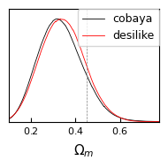

```python
g = plots.get_subplot_plotter()
g.triangle_plot([samples_bao_cobaya, samples_bao_desilike],
                 params=['Omega_m'], markers={'Omega_m': cosmo['Omega_m']})
```

### 'Static' bindings

Other inference codes (CosmoSIS, MontePython) typically require the likelihood to be written down in a file, such that it is imported by the code. Let's illustrate this, still with Cobaya.

```python
%%file _tests/bao_likelihood.py

dirname = '.'

def BAOLikelihood(cosmo='external'):
    import numpy as np
    from desilike.observables.galaxy_clustering import BAOCompressionObservable
    from desilike.likelihoods import ObservablesGaussianLikelihood
    # cosmo = 'external' to tell desilike that cosmo will be provided externally
    observable1 = BAOCompressionObservable(data=[1., 1.], quantities=['qpar', 'qper'], z=0.5, cosmo=cosmo)
    observable2 = BAOCompressionObservable(data=[1.], quantities=['qiso'], z=1., cosmo=cosmo)
    likelihood = ObservablesGaussianLikelihood([observable1, observable2],
                                               covariance=np.diag([0.002, 0.002, 0.005]))
    return likelihood

if __name__ == '__main__':
    from desilike.bindings import CobayaLikelihoodGenerator
    # We could provide a list of Likelihoods, which will all be written at once
    CobayaLikelihoodGenerator(dirname=dirname)([BAOLikelihood], kw_like={'cosmo': 'external'})
```

```
Writing _tests/bao_likelihood.py
```

Let's generate the static bindings by calling the above Python script

```python
%%bash
cd _tests/
python bao_likelihood.py
```

```
bash: /home/adematti/anaconda3/envs/cosmodesi-main/lib/libtinfo.so.6: no version information available (required by bash)
No GPU/TPU found, falling back to CPU. (Set TF_CPP_MIN_LOG_LEVEL=0 and rerun for more info.)
```

Let's take a look at the generated files:

- the Python module containing the Cobaya likelihood: `bao_likelihood.py`
- imported in the `__init__.py`
- the `.yaml` config file containing the nuisance parameters (none in this case)

```python
!ls -la _tests/cobaya_bindings
```

```
/bin/bash: /home/adematti/anaconda3/envs/cosmodesi-main/lib/libtinfo.so.6: no version information available (required by /bin/bash)
total 20
drwxr-xr-x 2 adematti idphp 4096 août  29 17:49 .
drwxr-xr-x 3 adematti idphp 4096 août  29 17:49 ..
-rw-r--r-- 1 adematti idphp  477 août  29 17:49 bao_likelihood.py
-rw-r--r-- 1 adematti idphp   31 août  29 17:49 BAOLikelihood.yaml
-rw-r--r-- 1 adematti idphp   30 août  29 17:49 __init__.py
```

```python
# %load _tests/cobaya/bao_likelihood.py
# NOTE: This code has been automatically generated by desilike.bindings.cobaya.factory.CobayaLikelihoodGenerator
from desilike.bindings.cobaya.factory import CobayaLikelihoodFactory

from desilike.bindings.base import load_from_file
BAOLikelihood = load_from_file('/home/adematti/Bureau/DESI/NERSC/cosmodesi/desilike-tutorials/_tests/bao_likelihood.py', 'BAOLikelihood')
BAOLikelihood = CobayaLikelihoodFactory(BAOLikelihood, 'BAOLikelihood', {'cosmo': 'external'}, __name__)
```

Now let's write the config file to run inference. This is pure Cobaya.

```python
%%file _tests/config_bao.yaml

theory:
  classy:
    extra_args:
      N_ncdm: 1
      N_ur: 2.0328

likelihood:
  cobaya_bindings.bao_likelihood.BAOLikelihood:
      python_path: _tests

params:
  Omega_m:
    prior:
      min: 0.1
      max: 1.
    ref:
      dist: norm
      loc: 0.3
      scale: 0.01
    latex: \Omega_{m}
  omega_b: 0.02237
  H0: 67.36
  As: 2.083e-09
  n_s: 0.9649
  tau_reio: 0.0544

sampler:
  mcmc:
    Rminus1_stop: 0.02

debug: False

output: _tests/chains_bao_cobaya/chain
```

```
Writing _tests/config_bao.yaml
```

Let's sample!

```python
!cobaya-run _tests/config_bao.yaml
```

```
/bin/bash: /home/adematti/anaconda3/envs/cosmodesi-main/lib/libtinfo.so.6: no version information available (required by /bin/bash)
[output] Output to be read-from/written-into folder '_tests/chains_bao_cobaya', with prefix 'chain'
[jax._src.xla_bridge] Unable to initialize backend 'cuda': module 'jaxlib.xla_extension' has no attribute 'GpuAllocatorConfig'
[jax._src.xla_bridge] Unable to initialize backend 'rocm': module 'jaxlib.xla_extension' has no attribute 'GpuAllocatorConfig'
[jax._src.xla_bridge] Unable to initialize backend 'tpu': INVALID_ARGUMENT: TpuPlatform is not available.
[jax._src.xla_bridge] *WARNING* No GPU/TPU found, falling back to CPU. (Set TF_CPP_MIN_LOG_LEVEL=0 and rerun for more info.)
[classy] `classy` module loaded successfully from /home/adematti/anaconda3/envs/cosmodesi-main/lib/python3.10/site-packages/classy-3.2.0-py3.10-linux-x86_64.egg
[BAOCompressionObservable] Found quantities ['qpar', 'qper'].
[BAOCompressionObservable] Found quantities ['qiso'].
[mcmc] Getting initial point... (this may take a few seconds)
[model] Measuring speeds... (this may take a few seconds)
[model] Setting measured speeds (per sec): {cobaya_bindings.bao_likelihood.BAOLikelihood: 339.0, classy: 13.1}
[mcmc] Initial point: Omega_m:0.2746471
[mcmc] Covariance matrix not present. We will start learning the covariance of the proposal earlier: R-1 = 30 (would be 2 if all params loaded).
[mcmc] Sampling!
[mcmc] Progress @ 2023-08-29 17:49:38 : 1 steps taken, and 0 accepted.
[mcmc] Learn + convergence test @ 40 samples accepted.
[mcmc]  - Acceptance rate: 0.970
[mcmc]  - Convergence of means: R-1 = 7.340651 after 32 accepted steps
[mcmc]  - Updated covariance matrix of proposal pdf.
[mcmc] Learn + convergence test @ 80 samples accepted.
[mcmc]  - Acceptance rate: 0.914
[mcmc]  - Convergence of means: R-1 = 0.550439 after 64 accepted steps
[mcmc]  - Updated covariance matrix of proposal pdf.
[mcmc] Learn + convergence test @ 120 samples accepted.
[mcmc]  - Acceptance rate: 0.881
[mcmc]  - Convergence of means: R-1 = 0.163416 after 96 accepted steps
[mcmc]  - Updated covariance matrix of proposal pdf.
[mcmc] Learn + convergence test @ 160 samples accepted.
[mcmc]  - Acceptance rate: 0.821
[mcmc]  - Convergence of means: R-1 = 0.048575 after 128 accepted steps
[mcmc]  - Updated covariance matrix of proposal pdf.
[mcmc] Learn + convergence test @ 200 samples accepted.
[mcmc]  - Acceptance rate: 0.648
[mcmc]  - Convergence of means: R-1 = 0.240958 after 160 accepted steps
[mcmc]  - Updated covariance matrix of proposal pdf.
[mcmc] Learn + convergence test @ 240 samples accepted.
[mcmc]  - Acceptance rate: 0.568
[mcmc]  - Convergence of means: R-1 = 0.089333 after 192 accepted steps
[mcmc]  - Updated covariance matrix of proposal pdf.
```

[output cut: 20 more lines]

```
[mcmc] Learn + convergence test @ 480 samples accepted.
[mcmc]  - Acceptance rate: 0.499
[mcmc]  - Convergence of means: R-1 = 0.026411 after 384 accepted steps
[mcmc]  - Updated covariance matrix of proposal pdf.
[mcmc] Progress @ 2023-08-29 17:50:38 : 879 steps taken, and 482 accepted.
[mcmc] Learn + convergence test @ 520 samples accepted.
[mcmc]  - Acceptance rate: 0.503
[mcmc]  - Convergence of means: R-1 = 0.014406 after 416 accepted steps
[mcmc]  - Updated covariance matrix of proposal pdf.
[mcmc] Learn + convergence test @ 560 samples accepted.
[mcmc]  - Acceptance rate: 0.497
[mcmc]  - Convergence of means: R-1 = 0.010158 after 448 accepted steps
[mcmc]  - Convergence of bounds: R-1 = 0.093752 after 560 accepted steps
[mcmc] The run has converged!
[mcmc] Sampling complete after 560 accepted steps.
```

```
[000211.52] [0/1] 08-29 17:50  root                      WARNING  outlier fraction 0.12142857142857143
```

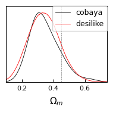

```python
# To load Cobaya samples from disk
from getdist.mcsamples import loadMCSamples
samples_bao_cobaya = loadMCSamples('_tests/chains_bao_cobaya/chain', settings={'ignore_rows': 0.5}).copy(label='cobaya')

g = plots.get_subplot_plotter()
g.triangle_plot([samples_bao_cobaya, samples_bao_desilike],
                 params=['Omega_m'], markers={'Omega_m': cosmo['Omega_m']})
```

### CosmoSIS

Let's apply the static bindings to CosmoSIS. The BAOLikelihood definition is exactly the same, we just need to generate new files with a simple CosmoSISLikelihoodGenerator call.

```python
%%file _tests/bao_likelihood.py

dirname = '.'

# The same as for Cobaya!
def BAOLikelihood(cosmo='external'):
    import numpy as np
    from desilike.observables.galaxy_clustering import BAOCompressionObservable
    from desilike.likelihoods import ObservablesGaussianLikelihood
    # cosmo = 'external' to tell desilike that cosmo will be provided externally
    observable1 = BAOCompressionObservable(data=[1., 1.], quantities=['qpar', 'qper'], z=0.5, cosmo=cosmo)
    observable2 = BAOCompressionObservable(data=[1.], quantities=['qiso'], z=1., cosmo=cosmo)
    likelihood = ObservablesGaussianLikelihood([observable1, observable2],
                                               covariance=np.diag([0.002, 0.002, 0.005]))
    return likelihood

if __name__ == '__main__':
    from desilike.bindings import CobayaLikelihoodGenerator, CosmoSISLikelihoodGenerator, MontePythonLikelihoodGenerator
    CobayaLikelihoodGenerator(dirname=dirname)([BAOLikelihood], kw_like={'cosmo': 'external'})
    # The only change!
    CosmoSISLikelihoodGenerator(dirname=dirname)([BAOLikelihood], kw_like={'cosmo': 'external'})
    # Let's directly generate the bindings for MontePython
    MontePythonLikelihoodGenerator(dirname=dirname)([BAOLikelihood], kw_like={'cosmo': 'external'})
```

```
Overwriting _tests/bao_likelihood.py
```

Let's generate the static bindings by calling the above Python script

```python
%%bash
cd _tests
python bao_likelihood.py
```

```
bash: /home/adematti/anaconda3/envs/cosmodesi-main/lib/libtinfo.so.6: no version information available (required by bash)
No GPU/TPU found, falling back to CPU. (Set TF_CPP_MIN_LOG_LEVEL=0 and rerun for more info.)
```

Let's take a look at the generated files:

```python
ls -la _tests/cosmosis
```

```
/bin/bash: /home/adematti/anaconda3/envs/cosmodesi-main/lib/libtinfo.so.6: no version information available (required by /bin/bash)
ls: impossible d'accéder à '_tests/cosmosis': Aucun fichier ou dossier de ce type
```

Now let's write the config file to run inference. This is pure CosmoSIS.

```python
%%file _tests/config_bao.ini

[DEFAULT]
fatal_errors = T

[runtime]
sampler = emcee

[output]
filename = _tests/chains_bao_cosmosis/chain.txt
format = text
verbosity = 0

[pipeline]
modules = consistency camb bao
values = _tests/values_bao.ini
likelihoods = BAOLikelihood  ; notice the name of the likelihood: the same as the *.py file
quiet = T
debug = F
timing = F

[consistency]
file = ${COSMOSIS_STD_DIR}/utility/consistency/consistency_interface.py

[camb]
file = ${COSMOSIS_STD_DIR}/boltzmann/camb/camb_interface.py
mode = background
feedback = 0
nz = 901

[bao]
file = _tests/cosmosis_bindings/BAOLikelihood.py

[emcee]
walkers = 6
samples = 600
nsteps = 20
```

```
Writing _tests/config_bao.ini
```

The `*values.ini` file containing parameter values and ranges

```python
%%file _tests/values_bao.ini

[cosmological_parameters]
; This is the only parameter being varied.
omega_m = 0.1 0.3 0.9
ombh2 = 0.02237
h0 = 0.6736
A_s = 2.083e-09
n_s = 0.9649
tau = 0.0544

mnu = 0.06
nnu = 3.046
num_massive_neutrinos = 1
omega_k = 0.0
w = -1.0
wa = 0.0
```

```
Writing _tests/values_bao.ini
```

Let's sample!

```python
!cosmosis _tests/config_bao.ini
```

```
/bin/bash: /home/adematti/anaconda3/envs/cosmodesi-main/lib/libtinfo.so.6: no version information available (required by /bin/bash)
Deprecated: The [pipeline] quiet option is deprecated.  Set [runtime] verbosity instead.
Setting up pipeline from parameter file _tests/config_bao.ini
-------------------------------------------------------------
No GPU/TPU found, falling back to CPU. (Set TF_CPP_MIN_LOG_LEVEL=0 and rerun for more info.)

Setting up module consistency
------------------------------

Setting up module camb
-----------------------

Setting up module bao
----------------------
Setup all pipeline modules


Parameter Priors
----------------
cosmological_parameters--omega_m                ~ U(0.1, 0.9)
cosmological_parameters--ombh2                  ~ delta(0.02237)
cosmological_parameters--h0                     ~ delta(0.6736)
cosmological_parameters--a_s                    ~ delta(2.083e-09)
cosmological_parameters--n_s                    ~ delta(0.9649)
cosmological_parameters--tau                    ~ delta(0.0544)
cosmological_parameters--mnu                    ~ delta(0.06)
cosmological_parameters--nnu                    ~ delta(3.046)
cosmological_parameters--num_massive_neutrinos  ~ delta(1)
cosmological_parameters--omega_k                ~ delta(0.0)
cosmological_parameters--w                      ~ delta(-1.0)
cosmological_parameters--wa                     ~ delta(0.0)

* Running sampler 1/1: emcee
* Running in serial mode.
* Saving output -> _tests/chains_bao_cosmosis/chain.txt
Generating starting positions in small ball around starting point
Begun sampling
Done 20 iterations of emcee. Acceptance fraction 0.975
Done 40 iterations of emcee. Acceptance fraction 0.867
Done 60 iterations of emcee. Acceptance fraction 0.867
```

[output cut: 14 more lines]

[output not shown]

```
LOADING CHAIN FROM FILE:  _tests/chains_bao_cosmosis/chain.txt
```

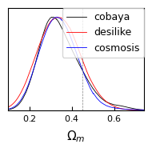

```python
# To load CosmoSIS samples from disk
from cosmosis import Inifile
from cosmosis.output import input_from_options
from getdist import MCSamples

ini = Inifile('_tests/config_bao.ini')
options = dict(ini.items('output'))
options['filename'] = '_tests/chains_bao_cosmosis/chain.txt'
column_names, data = input_from_options(options)[:2]
#print(column_names)
data = data[0].T
data = data[..., data.shape[-1] // 2::10]  # removing burnin and thinning
samples_bao_cosmosis = MCSamples(samples=[data[0]], weights=None, loglikes=-data[-1],
                                 names=['Omega_m'], label='cosmosis')

g = plots.get_subplot_plotter()
g.triangle_plot([samples_bao_cobaya, samples_bao_desilike, samples_bao_cosmosis],
                 params=['Omega_m'], markers={'Omega_m': cosmo['Omega_m']})
```

### MontePython

MontePython is not a Python package, so is not installed in the cosmodesi environment.

Let's install it locally! (it may take some time to download, because of the data sets).

```python
%%bash
cd _tests/
git clone https://github.com/brinckmann/montepython_public.git
```

```
bash: /home/adematti/anaconda3/envs/cosmodesi-main/lib/libtinfo.so.6: no version information available (required by bash)
Clonage dans 'montepython_public'...
Mise à jour des fichiers: 100% (1492/1492), fait.
```

We write the `.conf` file that specifies the path to the Boltzman code Class and Planck likelihoods.

```python
%%file _tests/montepython_public/default.conf

import os
path['cosmo'] = os.getenv('CLASS_STD_DIR')
path['clik'] = os.path.join(os.getenv('PLANCK_SRC_DIR'), 'code', 'plc_3.0', 'plc-3.1')
```

```
Writing _tests/montepython_public/default.conf
```

Let's take a look at the files previously generated by the static bindings:

- the package: `BAOLikelihood`
- with a (mandatory) `*.data` file specifying the likelihood name and nuisance parameter priors
- with `*.param` file specifying parameter ranges, to be copy-pasted in the input `.param` file (see below)
- with the `__init__.py` file containing the likelihood definition

As required by MontePython, we copy all this to the `montepython/likelihoods` directory.

```python
!ls -la _tests/montepython_bindings/BAOLikelihood
!cp -r _tests/montepython_bindings/BAOLikelihood _tests/montepython_public/montepython/likelihoods/
```

```
/bin/bash: /home/adematti/anaconda3/envs/cosmodesi-main/lib/libtinfo.so.6: no version information available (required by /bin/bash)
total 20
drwxr-xr-x 2 adematti idphp 4096 août  29 17:50 .
drwxr-xr-x 3 adematti idphp 4096 août  29 17:50 ..
-rw-r--r-- 1 adematti idphp   35 août  29 17:50 BAOLikelihood.data
-rw-r--r-- 1 adematti idphp   52 août  29 17:50 BAOLikelihood.param
-rw-r--r-- 1 adematti idphp  502 août  29 17:50 __init__.py
/bin/bash: /home/adematti/anaconda3/envs/cosmodesi-main/lib/libtinfo.so.6: no version information available (required by /bin/bash)
```

Now let's write the config file to run inference. This is pure MontePython.

```python
%%file _tests/conf_bao.param

data.experiments = ['BAOLikelihood']

#------ Parameter list -------
# data.parameters[class name] = [mean, min, max, 1-sigma, scale, role]

# Cosmological parameters list
data.parameters['Omega_m'] = [0.3, 0.1, 0.9, 0.1, 1., 'cosmo']
# Fixed parameters
data.parameters['omega_b'] = [0.02237, 0.001, 0.1, 0., 1., 'cosmo']
data.parameters['H0'] = [67.36, 0.1, 0.9, 0., 1., 'cosmo']
data.parameters['A_s'] = [2.083e-09, 1e-09, 3e-09, 0., 1., 'cosmo']
data.parameters['n_s'] = [0.9649, 0.9, 1.0, 0., 1., 'cosmo']
data.parameters['tau_reio'] = [0.0544, 0.02, 0.1, 0., 1., 'cosmo']

# Cosmo arguments
data.cosmo_arguments['k_pivot'] = 0.05
data.cosmo_arguments['N_ur'] = 2.0328
data.cosmo_arguments['N_ncdm'] = 1
data.cosmo_arguments['m_ncdm'] = 0.06
data.cosmo_arguments['T_ncdm'] = 0.71611

#------ MCMC parameters ----
data.N = 3000
data.write_step = 5
```

```
Writing _tests/conf_bao.param
```

Let's sample!

```python
!python _tests/montepython_public/montepython/MontePython.py run --conf _tests/montepython_public/default.conf -p _tests/conf_bao.param -o _tests/chains_bao_montepython
```

```
/bin/bash: /home/adematti/anaconda3/envs/cosmodesi-main/lib/libtinfo.so.6: no version information available (required by /bin/bash)
 /!\ PyMultiNest detected but MultiNest likely not installed correctly. You can
     safely ignore this if not running with option -m NS
Running Monte Python v3.6.0

with CLASS v3.2.0

Testing likelihoods for:
 ->BAOLikelihood

No GPU/TPU found, falling back to CPU. (Set TF_CPP_MIN_LOG_LEVEL=0 and rerun for more info.)
Creating _tests/chains_bao_montepython/2023-08-29_3000__1.txt


Deduced starting covariance matrix:
```

[output cut: 1623 more lines]

```
[001133.81] [0/1] 08-29 18:06  root                      WARNING  outlier fraction 0.14492753623188406
```

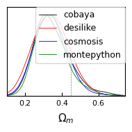

```python
# To load MontePython samples from disk
from datetime import date
from getdist.mcsamples import loadMCSamples
samples_bao_montepython = loadMCSamples('_tests/chains_bao_montepython/{}_3000_'.format(date.today()),
                                    settings={'ignore_rows': 0.5}).copy(label='montepython')

g = plots.get_subplot_plotter()
g.triangle_plot([samples_bao_cobaya, samples_bao_desilike, samples_bao_cosmosis, samples_bao_montepython],
                 params=['Omega_m'], markers={'Omega_m': cosmo['Omega_m']})
```

## Interlude: forecasts

So far we have input totally ad-hoc covariance matrices. Yet, one can use desilike to produce forecasts.

```python
from desilike.observables.galaxy_clustering import CutskyFootprint
from desilike.theories.galaxy_clustering import BAOPowerSpectrumTemplate, SimpleBAOWigglesTracerPowerSpectrumMultipoles
from desilike.likelihoods.galaxy_clustering import SNWeightedPowerSpectrumLikelihood
from desilike import Fisher

cosmo = DESI()

# Object holding the area and n(z) in (Mpc/h)^(-3)
footprint = CutskyFootprint(area=14000., zrange=np.linspace(0.8, 1.2, 10), nbar=np.full(10, 1e-4), cosmo=cosmo)
z = footprint.zavg

fo = cosmo.get_fourier()
s, s0 = fo.sigma8_z(z, of='delta_cb'), fo.sigma8_z(0., of='delta_cb')
b1 = 0.8 / (s / s0)  # prescription for linear bias
r = 0.5  # reconstruction factor
sigmaper = 9.4 * (s / 0.9)
f = fo.sigma8_z(z, of='theta_cb') / s
params = {'b1': b1, 'sigmapar': r * (1. + f) * sigmaper, 'sigmaper': r * sigmaper}  # fiducial model parameters
covariance_params = {'b1': b1, 'sigmapar': 0., 'sigmaper': 0.}  # fiducial covariance parameters (simple Kaiser model)
template = BAOPowerSpectrumTemplate(z=z, fiducial='DESI', apmode='qparqper')
theory = SimpleBAOWigglesTracerPowerSpectrumMultipoles(template=template) # this BAO model shifts wiggles only
for param in theory.init.params.select(basename='al*'):
    param.update(value=0., fixed=True)  # fixing broadband parameters (the wiggles only shift)

# For klim=(0.01, 0.5), we only use the information from the BAO feature in the power spectrum
likelihood = SNWeightedPowerSpectrumLikelihood(theories=theory, data=params, covariance=covariance_params,
                                               footprints=footprint, klim=(0.01, 0.5))
fisher = Fisher(likelihood)  # initializing Fisher
fisher_bao = fisher(**params).view(params=['qpar', 'qper'])  # computing Fisher prediction at fiducial parameters
```

```
[001136.51] [0/1] 08-29 18:06  Differentiation           INFO     Varied parameters: ['qpar', 'qper', 'b1', 'sigmas'].
[001136.60] [0/1] 08-29 18:06  Differentiation           INFO     Varied parameters: ['qpar', 'qper', 'b1', 'sigmas'].
[001137.04] [0/1] 08-29 18:06  Differentiation           INFO     Using finite-differentiation for parameter qpar.
[001137.15] [0/1] 08-29 18:06  Differentiation           INFO     Using finite-differentiation for parameter qper.
[001137.77] [0/1] 08-29 18:06  Differentiation           INFO     Using auto-differentiation for parameter b1.
[001138.06] [0/1] 08-29 18:06  Differentiation           INFO     Using auto-differentiation for parameter sigmas.
[001138.06] [0/1] 08-29 18:06  Differentiation           INFO     qpar grid is [0.998 1.    1.002].
[001138.06] [0/1] 08-29 18:06  Differentiation           INFO     qper grid is [0.998 1.    1.002].
```

```python
print(fisher_bao.to_stats(tablefmt='pretty'))
```

```
+-----+---------+
| FoM | 3601.51 |
+-----+---------+
+------+-------+-------+
|      | qpar  | qper  |
+------+-------+-------+
| mean | 1.000 | 1.000 |
| std  | 0.019 | 0.016 |
+------+-------+-------+
+------+---------+---------+
|      |  qpar   |  qper   |
+------+---------+---------+
| qpar | 3.6e-4  | -1.3e-4 |
| qper | -1.3e-4 | 2.6e-4  |
+------+---------+---------+
```

```python
quantities = ['qpar', 'qper']
# You can directly pass Fisher to BAOCompressionObservable
observable = BAOCompressionObservable(data=fisher_bao, covariance=fisher_bao,
                                      quantities=quantities, z=z)
# Or...
observable = BAOCompressionObservable(data=fisher_bao.mean(quantities),
                                      covariance=fisher_bao.covariance(quantities),
                                      quantities=quantities, z=z)
```

This observable can be passed to a likelihood, just as previously, to further run cosmological inference.

## ShapeFit likelihood

ShapeFit compressed likelihoods are similar to BAO compressed likelihoods.

```python
from desilike.observables.galaxy_clustering import ShapeFitCompressionObservable

observable = ShapeFitCompressionObservable(data=[1., 1., 1., 0.], covariance=np.diag([0.01, 0.01, 0.01, 0.01]),
                                           quantities=['qpar', 'qper', 'df', 'dm'], z=1.)
# Let's define the likelihood from this observable
likelihood = ObservablesGaussianLikelihood(observable)
```

This observable can be passed to a likelihood, just as previously, to further run cosmological inference.